# Using Vector Embeddings For Sentiment Analysis

Rod Acosta, Kevin Furbish, Ibrahim Khan, Anthony Washington

## 3. Analysis and Results

### 3.1 Dataset Description

For sentiment analysis, this project will use a data set of movie reviews from IMDB (Maas et al. 2011). The dataset includes 25,000 movie reviews, and since some movies are reviewed more often than others, the dataset includes a maximum of 30 reviews for any particular movie. The dataset includes only the top 5,000 most frequent words, however the top 50 most frequent words are also discarded as they are unlikely to contribute much to sentiment context. IMDB reviews include a star rating of 1 to 10 stars, and these ratings have been converted to a 0-1 scale for use as a sentiment classification label in the dataset.

The TensorFlow package (Abadi et al. 2015) includes this dataset in a vectorized format which is ideal for use in neural networks. The vectorization process starts by assigning each word that appears in the vocabularly (i.e. all the unique words in the dataset) with a unique number for a numeric substitution value. Then each word in the original text observation is replaced with the substitution number assigned to that word. Every observation is translated in this same way to convert from a string made up of words to a vector of integers. An example follows below:

Observation #1: “this is fun”

Observation #2: “fun times ahead”

Observation #3: “fun is ahead of times”

Based on the three above observations, there are six unique words in the vocabularly. These six unique words would each be assigned a numeric value. Thus the vocabulary list would be [1-this, 2-is, 3-fun, 4-times, 5-ahead, 6-of]. To vectorize the strings, the numeric values for each of those words are added to a integer vector. The vectorized observations are shown below.

Observation #1 vectorized: [1,2,3]

Observation #2 vectorized: [3,4,5]

Observation #3 vectorized: [3,2,5,6,4]

#### Install and Import Packages

#### Loading and preparing Training and Test Data

Load the tensorflow IMDB review dataset. Only the top most common 5000 words will be included. All other words will be replaced with a token representing an unknown word. Up to the first 500 words in a review are included in the training and test sets.

The neural network will be expecting batches of training examples that are 500 words long, so pad any observations shorter than 500 words with a token representing the padding word to get to the required 500 word length.

### Statistical Modeling

In this section a neural network model will be implemented using the keras package to learn embeddings for each of the words in the vocabulary. The goal is to learn multi-dimensional vectors where similar words are close in the vector-space, where similar means having a similar contextual meaning with regards to the training dataset and its sentiment classification. For example, “gem” and “favorite” would be highly similar in the context of a movie review, whereas in a general context they would not be so similar.

The number of dimensions of the output embedding will be varied and tested as part of the modeling process. The number of dimensions is an important hyperparameter since it will control how much compression of the training set occurs. A small number of dimensions results in a higher amount of compression, whereas a large number of dimensions allows for more detail to be captured by the embeddings. However, a larger number of dimensions can also lead to overfitting (Yin and Shen 2018).

Next the embedding model is trained. (Chollet and Allaire 2018) and (Monroe, n.d.) were important resources in coding the embedding training. As a first step, the model will be trained repeatedly with a different number of dimensions each time. Models will be trained using from 2 to 7 dimensions, and the testing accuracy will be recorded for each model.

The neural network model uses an embedding layer that will convert the words in the vocabulary to a multi-dimensional vector embedding once trained. The number of inputs to the embedding layer is 5000, which corresponds to the number of words in the vocabulary. The selected number of outputs for the embedding layer is the dimensionality of the embedding vector. As mentioned previously, this dimensionality will be varried to test the performance of the embeddings across different sizes of embedding dimensions. A second layer in the neural network model flattens the 3 dimensional tensor output from the embedding layer to a 2 dimensional tensor. Finally, a dense layer connects every output from the flatten layer to the final output layer. The model is trained using back propagation to predict the sentiment classification variable, and the final trained weights of the embedding layer are the embeddings for each corresponding word in the vocabulary.

```
782/782 - 2s - 2ms/step - acc: 0.8792 - loss: 0.2854
782/782 - 1s - 2ms/step - acc: 0.8782 - loss: 0.2879
782/782 - 1s - 1ms/step - acc: 0.8767 - loss: 0.2940
782/782 - 1s - 1ms/step - acc: 0.8761 - loss: 0.2967
782/782 - 2s - 2ms/step - acc: 0.8767 - loss: 0.2974
782/782 - 2s - 3ms/step - acc: 0.8743 - loss: 0.3038
```

```
      2       3       4       5       6       7
0.87924 0.87820 0.87672 0.87608 0.87672 0.87432
```

Surprisingly, an embedding of just 2 dimensions had the best accuracy. That may be the highest accuracy in predicting the binary sentiment classification, but the question is does that over compress the data and fail to represent the higher order patterns we hope the embedding models? As (Yin and Shen 2018) points out, “the impact of dimensionality on word embedding has not yet been fully understood…a word embedding with a small dimensionality is typically not expressive enough to capture all possible word relations, whereas one with a very large dimensionality suffers from over-fitting.”

The model with just 2 dimensions is tested to see how well it does on finding similar words, where similar is in the context of the sentiment of a movie review.

```
782/782 - 2s - 2ms/step - acc: 0.8805 - loss: 0.2855
```

The words “awful”, “mediocre”, “perfect” and “favorite” are some positive and negative words that could be found in a movie review. These test words are ysed to qualitatively test the embedding model by examining which words are found to be close to the test words.

```
    awful      lame alcoholic     sadly  relevant       are
1.0000000 1.0000000 1.0000000 0.9999998 0.9999998 0.9999998
```

```
  mediocre     effort     turkey   terrible stereotype     repeat
 1.0000000  1.0000000  1.0000000  0.9999999  0.9999999  0.9999998
```

```
  perfect    lovers      sing   manager      bath    donald
1.0000000 1.0000000 1.0000000 1.0000000 1.0000000 0.9999999
```

```
 favorite    deeply     round     marie  polanski    poetry
1.0000000 1.0000000 1.0000000 1.0000000 0.9999999 0.9999999
```

Some related words are found, but there are some other words that don’t seem to be very related. Overall the results don’t appear very good, so it seems embeddings using only 2 dimensions is not adequate despite the high accuracy found on the test set.

(Yin and Shen 2018) states that selecting the number of dimensions is often done ad hoc or by using grid search, with a common method being to train embeddings of different dimensions and evaluate them models using a functionality test like word analogy. A similar method was used here on a smaller scale where the embedding model was retrained using a larger number of dimensions and the performance of the related words test was compared. There was insufficient time to test many model variations, but it was important to test a larger number of dimensions to compare to the 2 dimension model. The test accuracy for the model previously trained with 7 dimensions was fairly close to the accuracy for 2 dimensions, so that embedding length was tested next.

```
782/782 - 2s - 2ms/step - acc: 0.8737 - loss: 0.3002
```

Here are the similar words for the same positive and negative words that were previously tested, but now tested using the new embedding model with higher dimensionality:

```
     awful ultimately    painful      sorry       fake    nowhere
 1.0000000  0.9979455  0.9972085  0.9959081  0.9958690  0.9951918
```

```
     mediocre         teeth   incompetent          main disappointing
    1.0000000     0.9969510     0.9960855     0.9958095     0.9956890
     generous
    0.9951327
```

```
   perfect      great    seeking    freedom tremendous  excellent
 1.0000000  0.9983013  0.9981593  0.9978434  0.9972070  0.9955212
```

```
 favorite    paulie excellent necessary     great   seeking
1.0000000 0.9986090 0.9984505 0.9983542 0.9971756 0.9971191
```

These results are better than the 2 dimension model, so it seems test accuracy isn’t a good method to determine how many dimensions should be included in the embedding model.

Next, the number of epochs used in training will be evaluated to see how that impacts the model performance.

```
782/782 - 1s - 1ms/step - acc: 0.8665 - loss: 0.3540
```

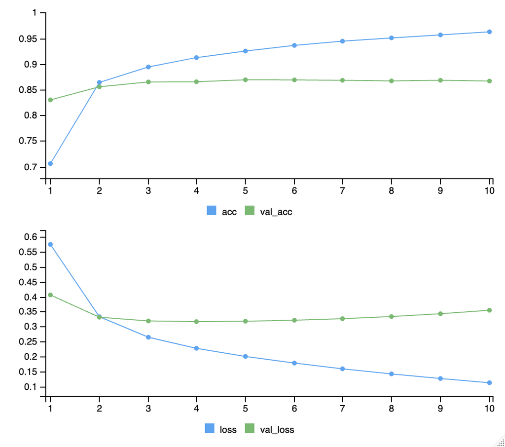

## Results

### Data and Visualization

## Data Visualization

- The Umap below shows the location of where all the words are embedded on a 2D plane. The words of the IMDB dataset are clustered densely around the origin of the graph.

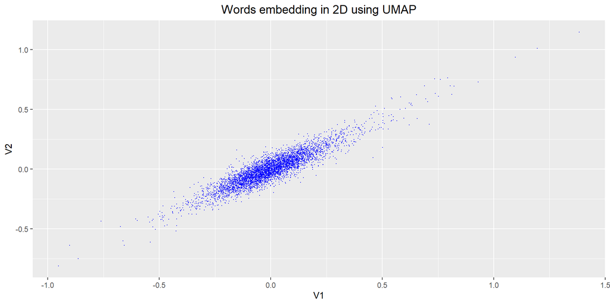

## Data Visualization

- The partial Umap below zooms in to the center of the Umap where it is most dense and labels the words to display all the words that are located near each other based on the embedding.

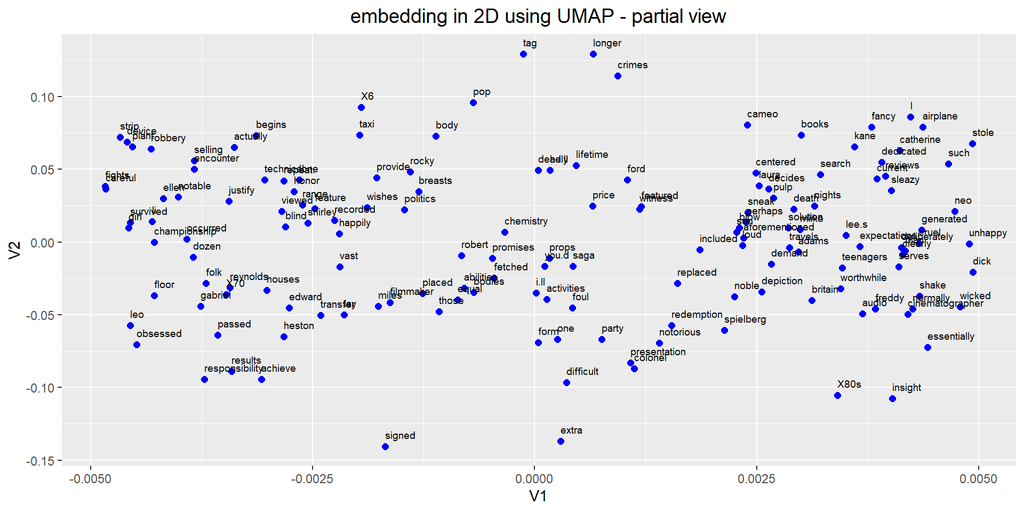

## Data Visualization

- The Umap below shows the 25 most similar words to the word “angry” according to the embedding.

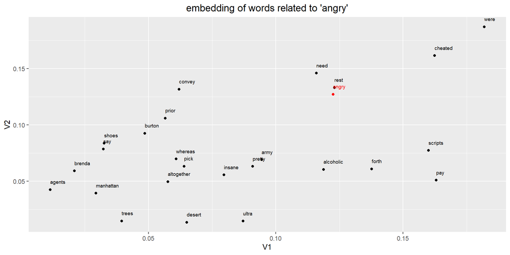

## Conclusion

- The model’s performance is noteworthy, given the constraints of training on only the top 5000 most common words, minimal data preprocessing, and limiting input sequences to the first 500 words of each review.
- These factors illustrate the model’s robustness and effectiveness in capturing the semantic relationships within the data.

## Refrences

Abadi, Martín, Ashish Agarwal, Paul Barham, Eugene Brevdo, Zhifeng Chen, Craig Citro, Greg S. Corrado, et al. 2015. “TensorFlow: Large-Scale Machine Learning on Heterogeneous Systems.” https://www.tensorflow.org/.

Chollet, Francois, and J. J. Allaire. 2018. *Deep Learning with r*. 1st ed. USA: Manning Publications Co.

Maas, Andrew L., Raymond E. Daly, Peter T. Pham, Dan Huang, Andrew Y. Ng, and Christopher Potts. 2011. “Learning Word Vectors for Sentiment Analysis.” In *Proceedings of the 49th Annual Meeting of the Association for Computational Linguistics: Human Language Technologies*, 142–50. Portland, Oregon, USA: Association for Computational Linguistics. http://www.aclweb.org/anthology/P11-1015.

Monroe, Burt. n.d. “Materials for Classes: ‘Text as Data’ (PLSC 597) at Penn State & ‘Advanced Text as Data: Natural Language Processing’ (2p) at Essex Summer School in Social Science Data Analysis.” *TextAsDataCourse*. https://burtmonroe.github.io/TextAsDataCourse/.

Yin, Zi, and Yuanyuan Shen. 2018. “On the Dimensionality of Word Embedding.” *Advances in Neural Information Processing Systems* 31.